# Apollo_case_study

### Problem Statemnet

The Aim is to find and prove the following :

• Which variables are significant in predicting the reason for hospitalization for different regions

• How well some variables like viral load, smoking, Severity Level describe the hospitalization charges

```python
import numpy as np
import pandas as pd
from scipy import stats
from matplotlib import pyplot as plt
import seaborn as sns
```

```python
from IPython.display import display, HTML
display(HTML("<style>.container { width:80% !important; }</style>"))
```

```python
df=pd.read_csv('apollo_hospitals.txt',index_col=None)
```

```python
df.head()
```

|  | Unnamed: 0 | age | sex | smoker | region | viral load | severity level | hospitalization charges |
| --- | --- | --- | --- | --- | --- | --- | --- | --- |
| 0 | 0 | 19 | female | yes | southwest | 9.30 | 0 | 42212 |
| 1 | 1 | 18 | male | no | southeast | 11.26 | 1 | 4314 |
| 2 | 2 | 28 | male | no | southeast | 11.00 | 3 | 11124 |
| 3 | 3 | 33 | male | no | northwest | 7.57 | 0 | 54961 |
| 4 | 4 | 32 | male | no | northwest | 9.63 | 0 | 9667 |

```python
df.drop(['Unnamed: 0'], axis=1,inplace=True)
```

```python
df.head()
```

|  | age | sex | smoker | region | viral load | severity level | hospitalization charges |
| --- | --- | --- | --- | --- | --- | --- | --- |
| 0 | 19 | female | yes | southwest | 9.30 | 0 | 42212 |
| 1 | 18 | male | no | southeast | 11.26 | 1 | 4314 |
| 2 | 28 | male | no | southeast | 11.00 | 3 | 11124 |
| 3 | 33 | male | no | northwest | 7.57 | 0 | 54961 |
| 4 | 32 | male | no | northwest | 9.63 | 0 | 9667 |

```python
df.shape
```

```
(1338, 7)
```

```python
df.dtypes
```

```
age                          int64
sex                         object
smoker                      object
region                      object
viral load                 float64
severity level               int64
hospitalization charges      int64
dtype: object
```

```python
df.describe()
```

|  | age | viral load | severity level | hospitalization charges |
| --- | --- | --- | --- | --- |
| count | 1338.000000 | 1338.000000 | 1338.000000 | 1338.000000 |
| mean | 39.207025 | 10.221233 | 1.094918 | 33176.058296 |
| std | 14.049960 | 2.032796 | 1.205493 | 30275.029296 |
| min | 18.000000 | 5.320000 | 0.000000 | 2805.000000 |
| 25% | 27.000000 | 8.762500 | 0.000000 | 11851.000000 |
| 50% | 39.000000 | 10.130000 | 1.000000 | 23455.000000 |
| 75% | 51.000000 | 11.567500 | 2.000000 | 41599.500000 |
| max | 64.000000 | 17.710000 | 5.000000 | 159426.000000 |

- **Severity Level**: This is an integer indicating how severe the patient is
- **Viral Load**: Viral load refers to the amount of virus in an infected person's blood. This is expressed as the number of viral particles in each milliliter of blood. Higher viral load can have different implications for different viruses but typically means the infection is progressing

```python
df.describe(include='object')
```

|  | sex | smoker | region |
| --- | --- | --- | --- |
| count | 1338 | 1338 | 1338 |
| unique | 2 | 2 | 4 |
| top | male | no | southeast |
| freq | 676 | 1064 | 364 |

```python
df.isnull().sum()
```

```
age                        0
sex                        0
smoker                     0
region                     0
viral load                 0
severity level             0
hospitalization charges    0
dtype: int64
```

```python
df.info()
```

```
<class 'pandas.core.frame.DataFrame'>
RangeIndex: 1338 entries, 0 to 1337
Data columns (total 7 columns):
 #   Column                   Non-Null Count  Dtype
---  ------                   --------------  -----
 0   age                      1338 non-null   int64
 1   sex                      1338 non-null   object
 2   smoker                   1338 non-null   object
 3   region                   1338 non-null   object
 4   viral load               1338 non-null   float64
 5   severity level           1338 non-null   int64
 6   hospitalization charges  1338 non-null   int64
dtypes: float64(1), int64(3), object(3)
memory usage: 73.3+ KB
```

Data does not have any null values

```python
# Unique value analysis
for i in df.columns:
    print(i,"has",df[i].nunique(),"unique values ")
```

[output not shown]

```python
for i in df.columns:
    print(i,"has ", df[i].nunique(),"unique values")
```

```
age has  47 unique values
sex has  2 unique values
smoker has  2 unique values
region has  4 unique values
viral load has  462 unique values
severity level has  6 unique values
hospitalization charges has  1320 unique values
```

```python
def find_outliers_IQR(df):

    q1=df.quantile(0.25)


    q3=df.quantile(0.75)

    IQR=q3-q1

    outliers = df[((df<(q1-1.5*IQR)) | (df>(q3+1.5*IQR)))]

    return outliers
```

## Univariate Analysis

###### Age

```python
df['age'].mean()
```

```
39.20702541106129
```

```python
# outlier check
find_outliers_IQR(df['age'])
```

```
Series([], Name: age, dtype: int64)
```

```python
df['age'].describe()
```

```
count    1338.000000
mean       39.207025
std        14.049960
min        18.000000
25%        27.000000
50%        39.000000
75%        51.000000
max        64.000000
Name: age, dtype: float64
```

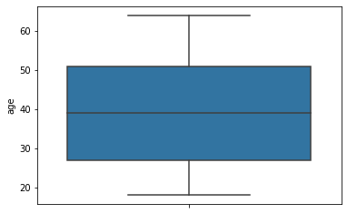

```python
sns.boxplot(data=df,y='age')
```

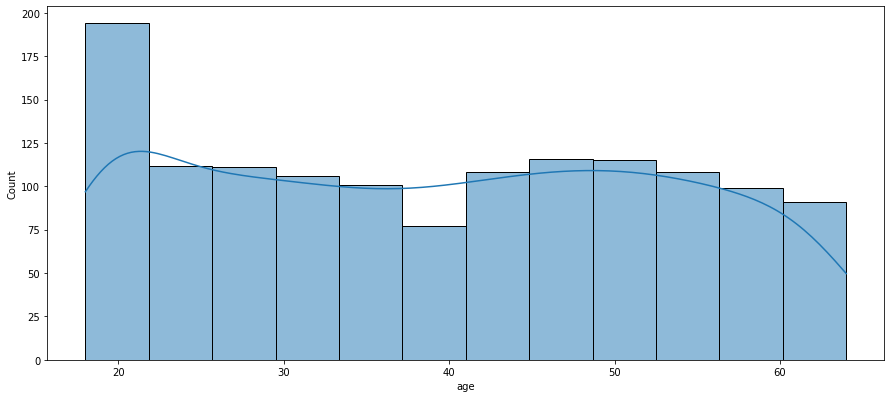

```python
plt.figure(figsize=(15, 6.5))
sns.histplot(data=df,x=df['age'],kde=True)
```

- Age column has no outliers
- Average age of a patient is 39 years

###### sex

```python
df['sex'].value_counts()
```

```
male      676
female    662
Name: sex, dtype: int64
```

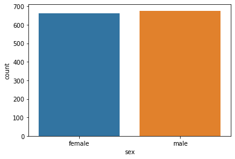

```python
sns.countplot(data=df,x='sex')
```

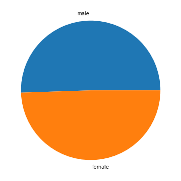

```python
plt.figure(figsize=(15, 6.5))
y=np.array(df['sex'].value_counts()/len(df))
mylabels = ["male", "female"]
myexplode = [0, 0]

plt.pie(y, labels = mylabels,explode=myexplode)
plt.show()
```

```python
df['sex'].value_counts()/len(df)
```

```
male      0.505232
female    0.494768
Name: sex, dtype: float64
```

###### Smoker

```python
df['smoker'].value_counts()
```

```
no     1064
yes     274
Name: smoker, dtype: int64
```

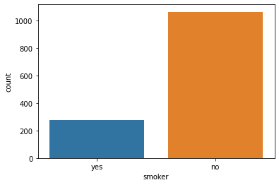

```python
sns.countplot(data=df,x='smoker')
```

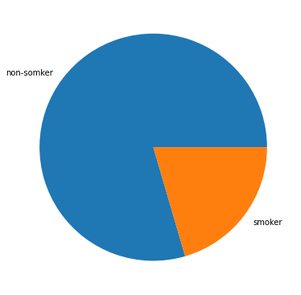

```python
plt.figure(figsize=(15, 6.5))
y=np.array(df['smoker'].value_counts()/len(df))
mylabels = ["non-somker", "smoker"]
myexplode = [0, 0]

plt.pie(y, labels = mylabels,explode=myexplode)
plt.show()
```

```python
df['smoker'].value_counts()/len(df)
```

```
no     0.795217
yes    0.204783
Name: smoker, dtype: float64
```

80% of people are non-smokers

###### region

```python
df['region'].value_counts()
```

```
southeast    364
northwest    325
southwest    325
northeast    324
Name: region, dtype: int64
```

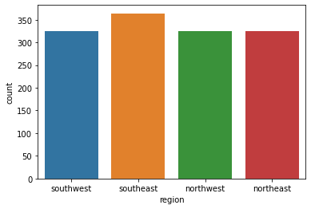

```python
sns.countplot(data=df,x='region')
```

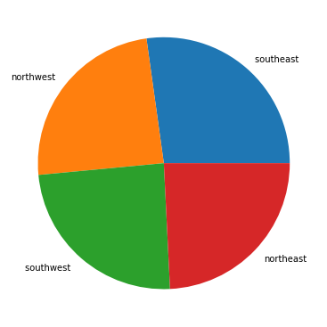

```python
plt.figure(figsize=(15, 6.5))
y=np.array(df['region'].value_counts()/len(df))
mylabels = ["southeast ", "northwest","southwest ","northeast"]

plt.pie(y, labels = mylabels)
plt.show()
```

```python
df['region'].value_counts()/len(df)
```

```
southeast    0.272048
northwest    0.242900
southwest    0.242900
northeast    0.242152
Name: region, dtype: float64
```

- data is well distributed

###### viral load

```python
df['viral load'].mean()
```

```
10.221233183856526
```

```python
len(find_outliers_IQR(df['viral load']))
```

```
9
```

- There are 9 outliers in the data

```python
find_outliers_IQR(df['viral load'])
```

```
116     16.35
286     16.02
401     15.84
543     15.80
847     16.79
860     15.87
1047    17.53
1088    15.91
1317    17.71
Name: viral load, dtype: float64
```

```python
df['viral load'].describe()
```

```
count    1338.000000
mean       10.221233
std         2.032796
min         5.320000
25%         8.762500
50%        10.130000
75%        11.567500
max        17.710000
Name: viral load, dtype: float64
```

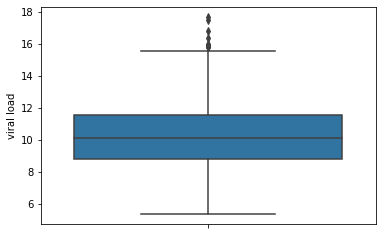

```python
sns.boxplot(data=df,y=df['viral load'])
```

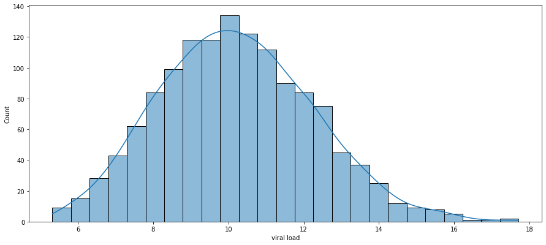

```python
plt.figure(figsize=(15, 6.5))
sns.histplot(data=df,x=df['viral load'],kde=True)
```

###### severity level

```python
df['severity level'].value_counts()
```

```
0    574
1    324
2    240
3    157
4     25
5     18
Name: severity level, dtype: int64
```

```python
df['severity level'].value_counts()*100/len(df)
```

```
0    42.899851
1    24.215247
2    17.937220
3    11.733931
4     1.868460
5     1.345291
Name: severity level, dtype: float64
```

- Only 3% of patients have severity levels 4 and 5.

```python
df['severity level'].describe()
```

```
count    1338.000000
mean        1.094918
std         1.205493
min         0.000000
25%         0.000000
50%         1.000000
75%         2.000000
max         5.000000
Name: severity level, dtype: float64
```

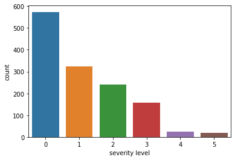

```python
sns.countplot(data=df,x='severity level')
```

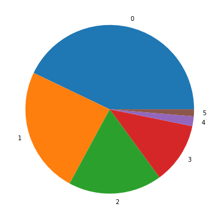

```python
plt.figure(figsize=(15, 6.5))
y=np.array(df['severity level'].value_counts()/len(df))
mylabels = ["0", "1","2 ","3","4","5"]

plt.pie(y, labels = mylabels)
plt.show()
```

```python
df['severity level'].value_counts()/len(df)
```

```
0    0.428999
1    0.242152
2    0.179372
3    0.117339
4    0.018685
5    0.013453
Name: severity level, dtype: float64
```

- 67% of patients have either zero or one level of severity

###### hospitalization charges

```python
df['hospitalization charges'].mean()
```

```
33176.058295964125
```

```python
df_hc=find_outliers_IQR(df['hospitalization charges'])
df_hc
```

```
14       99029
19       92094
23       94255
29       96778
30       88964
         ...
1300    156482
1301    116795
1303     94574
1313     90994
1323    109741
Name: hospitalization charges, Length: 139, dtype: int64
```

```python
lis=list(df_hc.index.values)
df_outliers_hc=df[df.index.isin(lis)]
```

```python
df_outliers_hc[df_outliers_hc['smoker']=='no']
```

|  | age | sex | smoker | region | viral load | severity level | hospitalization charges |
| --- | --- | --- | --- | --- | --- | --- | --- |
| 242 | 55 | female | no | southwest | 8.93 | 1 | 87900 |
| 1012 | 61 | female | no | southeast | 11.11 | 4 | 91451 |
| 1206 | 59 | female | no | southwest | 11.60 | 2 | 92277 |

```python
len(find_outliers_IQR(df['hospitalization charges']))
```

```
139
```

```python
len(df_outliers_hc[df_outliers_hc['smoker']=='no'])/len(find_outliers_IQR(df['hospitalization charges']))
```

```
0.02158273381294964
```

```python
len(df_outliers_hc[df_outliers_hc['smoker']=='yes'])/len(find_outliers_IQR(df['hospitalization charges']))
```

```
0.9784172661870504
```

- 97% of the outliers in hospitalization charges are smokers

```python
df['hospitalization charges'].describe()
```

```
count      1338.000000
mean      33176.058296
std       30275.029296
min        2805.000000
25%       11851.000000
50%       23455.000000
75%       41599.500000
max      159426.000000
Name: hospitalization charges, dtype: float64
```

```python
min(find_outliers_IQR(df['hospitalization charges']))
```

```
86545
```

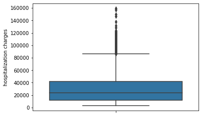

```python
sns.boxplot(data=df,y=df['hospitalization charges'])
```

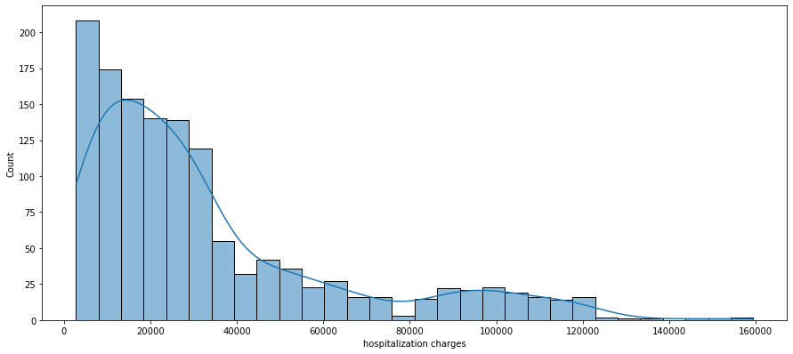

```python
plt.figure(figsize=(15, 6.5))
sns.histplot(data=df,x=df['hospitalization charges'],kde=True) # this is a log-normal graph we can convert it to normal distribution
```

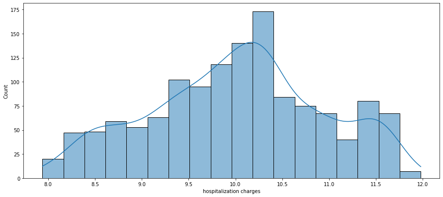

```python
plt.figure(figsize=(15, 6.5))
sns.histplot(x=np.log(df['hospitalization charges']),kde=True)
```

## Bi-variate Analysis

###### smoker vs hospitalization charges

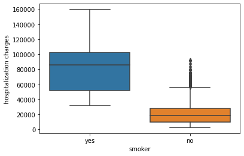

```python
sns.boxplot(data=df,x=df['smoker'],y=df['hospitalization charges'])
```

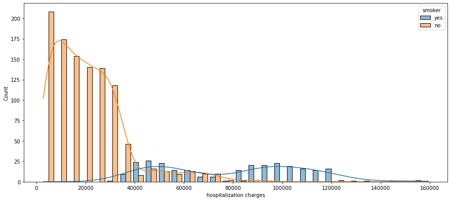

```python
plt.figure(figsize=(15, 6.5))
sns.histplot(data=df, x=df['hospitalization charges'], y=None, hue=df['smoker'],kde=True, multiple="dodge", shrink=0.8)
```

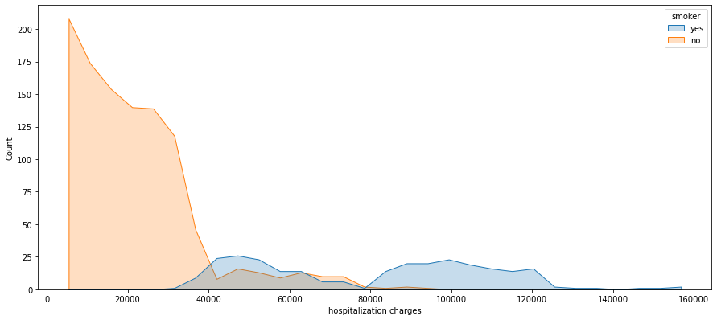

```python
plt.figure(figsize=(15, 6.5))
sns.histplot(data=df, x=df['hospitalization charges'], y=None, hue=df['smoker'], element='poly')
```

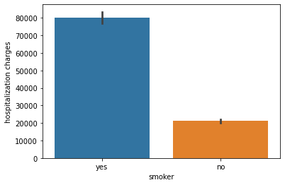

```python
sns.barplot(x = df['smoker'], y = df['hospitalization charges'], data=df, estimator=np.mean)
plt.show()
```

```python
print("Average Hospitalization chargers of  non smokers :",df[df['smoker']=='no']['hospitalization charges'].mean())
print("Average Hospitalization chargers of smokers :",df[df['smoker']=='yes']['hospitalization charges'].mean())
```

```
Average Hospitalization chargers of  non smokers : 21085.6757518797
Average Hospitalization chargers of smokers : 80125.57299270073
```

- Smokers has more hospitalization charges

###### smoker vs viral load

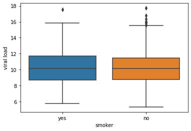

```python
sns.boxplot(data=df,x=df['smoker'],y=df['viral load'])
```

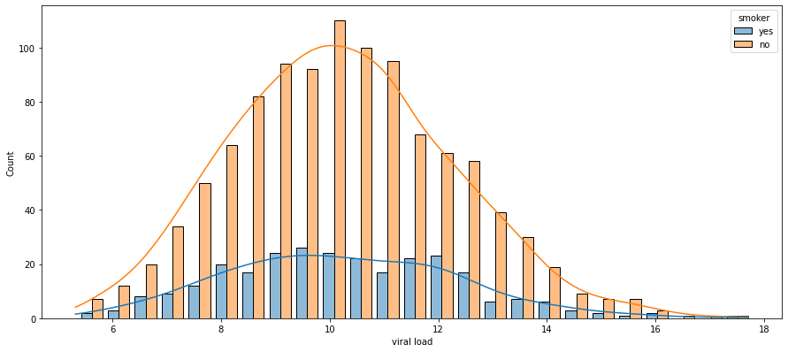

```python
plt.figure(figsize=(15, 6.5))
sns.histplot(data=df, x=df['viral load'], y=None, hue=df['smoker'],kde=True, multiple="dodge", shrink=0.8)
```

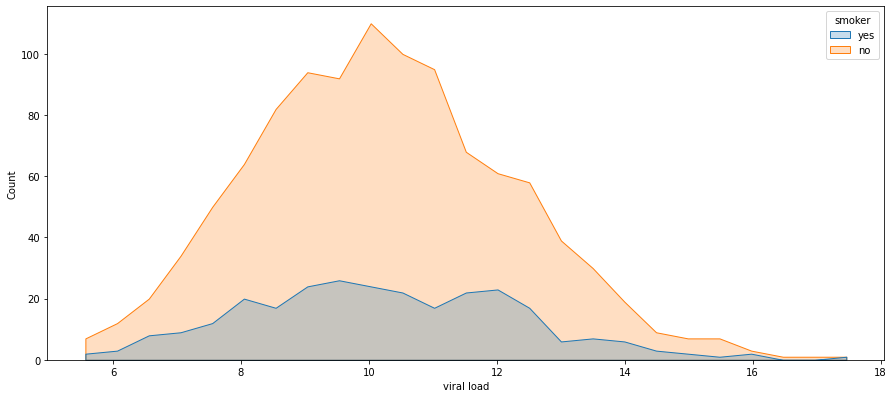

```python
plt.figure(figsize=(15, 6.5))
sns.histplot(data=df, x=df['viral load'], y=None, hue=df['smoker'], element='poly')
```

```python
print("Average Viral load of non smokers :",df[df['smoker']=='no']['viral load'].mean())
print("Average Viral load of smokers :",df[df['smoker']=='yes']['viral load'].mean())
```

```
Average Viral load of non smokers : 10.217377819548888
Average Viral load of smokers : 10.236204379562054
```

###### smoker vs severity level

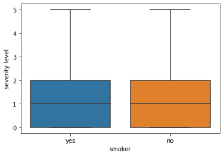

```python
sns.boxplot(data=df,x=df['smoker'],y=df['severity level'])
```

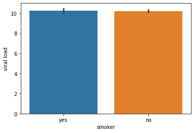

```python
sns.barplot(x = df['smoker'], y = df['viral load'], data=df, estimator=np.mean)
plt.show()
```

```python
pd.crosstab(index=df["smoker"], columns=df["severity level"],margins=True,normalize='index')*100
```

| severity level smoker | 0 | 1 | 2 | 3 | 4 | 5 |
| --- | --- | --- | --- | --- | --- | --- |
| no | 43.139098 | 24.718045 | 17.387218 | 11.090226 | 2.067669 | 1.597744 |
| yes | 41.970803 | 22.262774 | 20.072993 | 14.233577 | 1.094891 | 0.364964 |
| All | 42.899851 | 24.215247 | 17.937220 | 11.733931 | 1.868460 | 1.345291 |

##### sex vs hospitalization charges

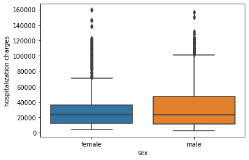

```python
sns.boxplot(data=df,x=df['sex'],y=df['hospitalization charges'])
```

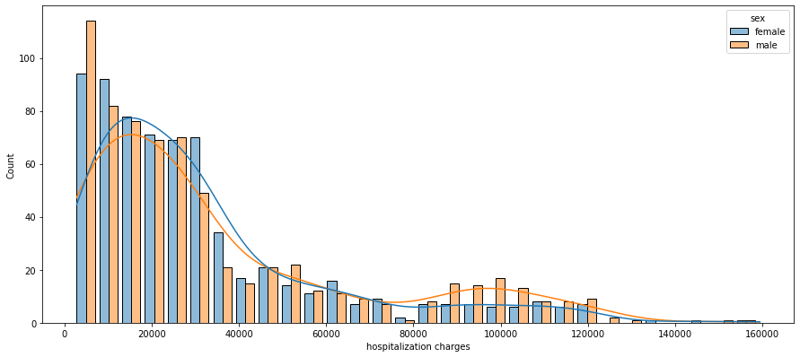

```python
plt.figure(figsize=(15, 6.5))
sns.histplot(data=df, x=df['hospitalization charges'], y=None, hue=df['sex'],kde=True, multiple="dodge", shrink=0.8)
```

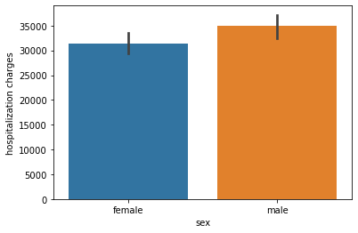

```python
sns.barplot(x = df['sex'], y = df['hospitalization charges'], data=df, estimator=np.mean)
plt.show()
```

```python
df[df['sex']=='male']['hospitalization charges'].mean()
```

```
34891.88461538462
```

```python
df[df['sex']=='female']['hospitalization charges'].mean()
```

```
31423.945619335347
```

- males spend more then women on hospitals

```python
pd.crosstab(index=df["sex"], columns=df["severity level"],margins=True)
```

| severity level sex | 0 | 1 | 2 | 3 | 4 | 5 | All |
| --- | --- | --- | --- | --- | --- | --- | --- |
| female | 289 | 158 | 119 | 77 | 11 | 8 | 662 |
| male | 285 | 166 | 121 | 80 | 14 | 10 | 676 |
| All | 574 | 324 | 240 | 157 | 25 | 18 | 1338 |

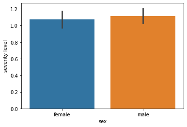

```python
sns.barplot(x = df['sex'], y = df['severity level'], data=df, estimator=np.mean)
plt.show()
```

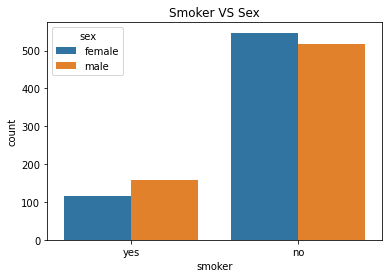

```python
sns.countplot(x=df['smoker'],hue='sex', data=df)
plt.title("Smoker VS Sex")
```

```python
df[df['smoker']=='yes']['sex'].value_counts()*100/len(df[df['smoker']=='yes'])
```

```
male      58.029197
female    41.970803
Name: sex, dtype: float64
```

- 58% of smokers are male

```python
df[df['smoker']=='yes']['region'].value_counts()*100/len(df[df['smoker']=='yes'])
```

```
southeast    33.211679
northeast    24.452555
southwest    21.167883
northwest    21.167883
Name: region, dtype: float64
```

- 33% of smokers are from southeast region

```python
df[df['smoker']=='yes']['severity level'].value_counts()*100/len(df[df['smoker']=='yes'])
```

```
0    41.970803
1    22.262774
2    20.072993
3    14.233577
4     1.094891
5     0.364964
Name: severity level, dtype: float64
```